[▶ Run this notebook in VEClim Tutorials](https://veclim.com/tutorials/hub/spawn?file_path=tutorials/Nicosia2025/sPop/sPop_R_tutorial.ipynb)

# Introduction

In this tutorial, we will explore a modelling framework that refines the **traditional degree-day approach** for describing larval development in relation to temperature. This framework is implemented in the [**Population package**](https://kerguler.github.io/Population/) and the companion [**PopJSON language**](https://kerguler.github.io/PopJSON/), designed to make population modelling more transparent, flexible, and reproducible.

The approach is also described in recent publications [Erguler et al. 2018, *F1000Research*](https://doi.org/10.12688/f1000research.15824.3) and [Erguler et al. 2022, *Scientific Reports*](https://doi.org/10.1038/s41598-022-15806-2).

### From Degree-Days to Data-Driven Development

Traditionally, growth is calculated by how many **degree-days** an organism accumulates above a baseline temperature.

For example:

- If larvae require at least 10 °C to grow, then spending one day at 11 °C counts as one degree-day.
- A day at 12 °C counts as two degree-days, and so on.

Instead of assuming a perfectly linear relationship between temperature and development, we allow for a complex dependencies, **species-specific, non-linear functions**, informed by **experimental data**. For instance,

- If larvae take 20 days to complete development at 20 °C, we assume they accumulate 1/20 of their development each day.
- At 30 °C, if development takes 5 days, then accumulation proceeds at 1/5 per day.

Our model relaxes the idea of a **fixed heat accumulation threshold**.

- Instead of requiring, for example, exactly 3,000 degree-days for development, we treat development time as a **distribution**.
- A population might develop around 30 days with some variability.
- This variability can be described using an **Erlang distribution** or other probabilistic approaches.

Finally, our model incorporates **multiple time-dependent processes** acting on a population. We assume that each process realises in sequence and dynamically structures the population into a set of pseudo-stages, each with a specific time distribution.

This tutorial will guide you through building such models step by step, using [Population](https://kerguler.github.io/Population/) and [PopJSON](https://kerguler.github.io/PopJSON/) to put these concepts into practice.

### Let's use models/example.json to represent larval growth dynamics.

Please refer to [**Population package**](https://kerguler.github.io/Population/) and [**PopJSON language**](https://kerguler.github.io/PopJSON/) for descriptions of what's possible.

```
[1] "Model translated to models/example.c"
[2] "Model file created: models/example.dylib"
```

```
Loaded model with: 1 pops, 0 pars, 0 ints, 0 envs.
```

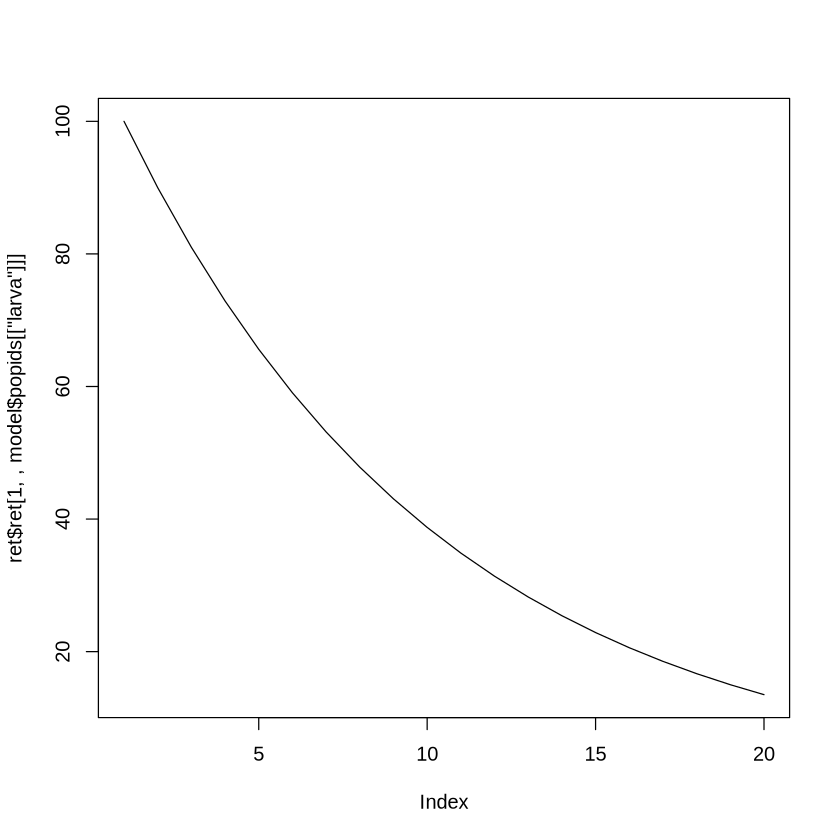

# Semi-field experiments

Let's try investigating something more complex but realistic. In 2022, we published an analysis using the set of semi-field experiments on immature stage development of *Culex pipiens* biotype *molestus*, performed by Dusan Petric's group. Please refer to [Erguler et al. 2022, *Scientific Reports*](https://doi.org/10.1038/s41598-022-15806-2) for more information.

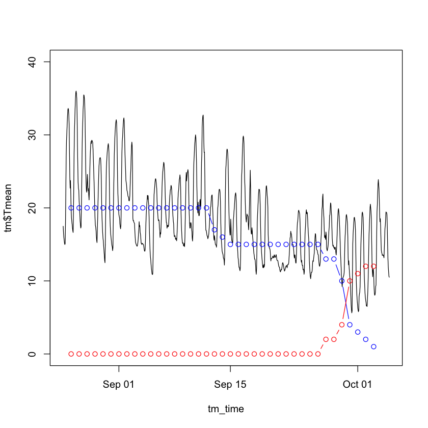

We propose an equation to link temperature to larva development and survival. The double sigmoidal is my favourite for its flexibility and ease of interpretation.

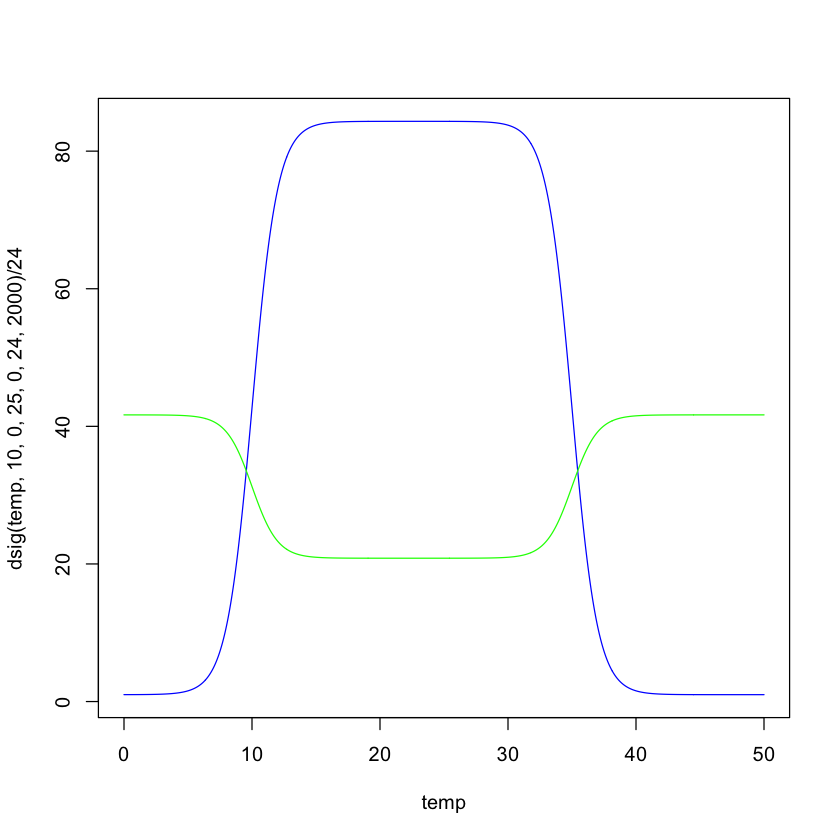

Let's go over the rest one step at a time, together...

```
[1] "Reading model file: models/model_larva.json"
[2] "Model translated to models/model_larva.c"
[3] "Model file created: models/model_larva.dylib"
```

```
Loaded model with: 1 pops, 12 pars, 4 ints, 1 envs.
```

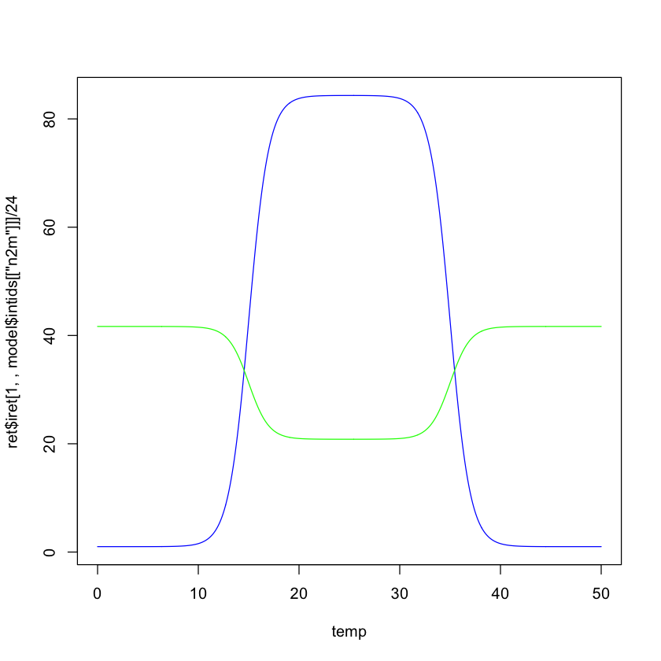

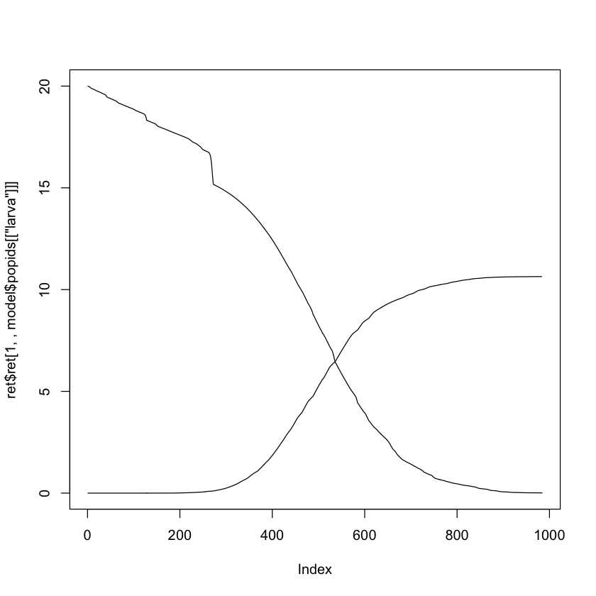

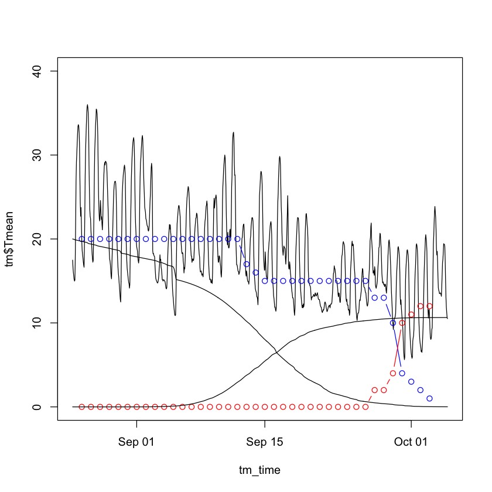

3722.04044709227

```
$par
 [1]    9.892222    5.983674   50.000000    6.000000   14.029705 4550.024496
 [7]   50.000000    6.000000  -10.000000   -6.000000  465.430554  946.066874

$value
[1] 232.7981

$counts
function gradient
     137      137

$convergence
[1] 0

$message
[1] "CONVERGENCE: REL_REDUCTION_OF_F <= FACTR*EPSMCH"
```

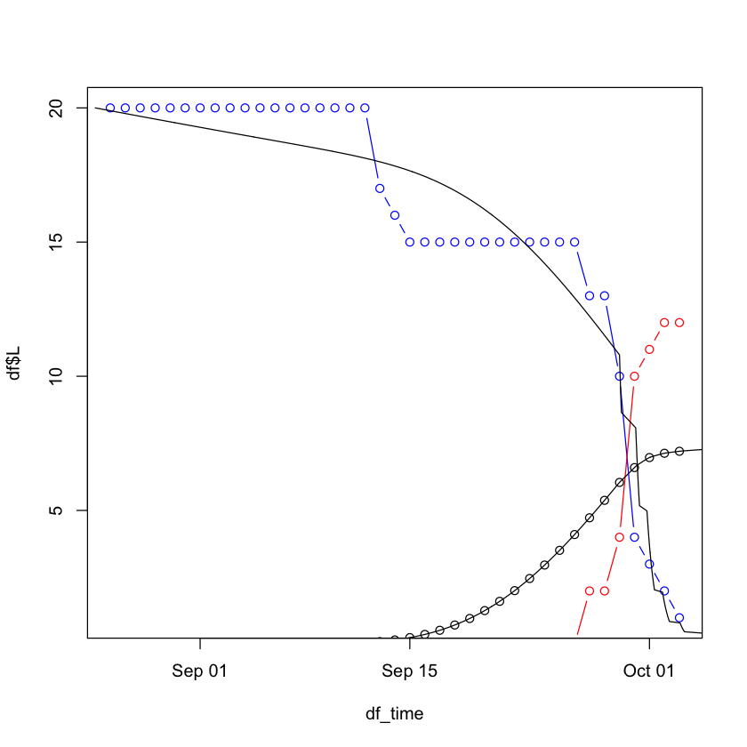

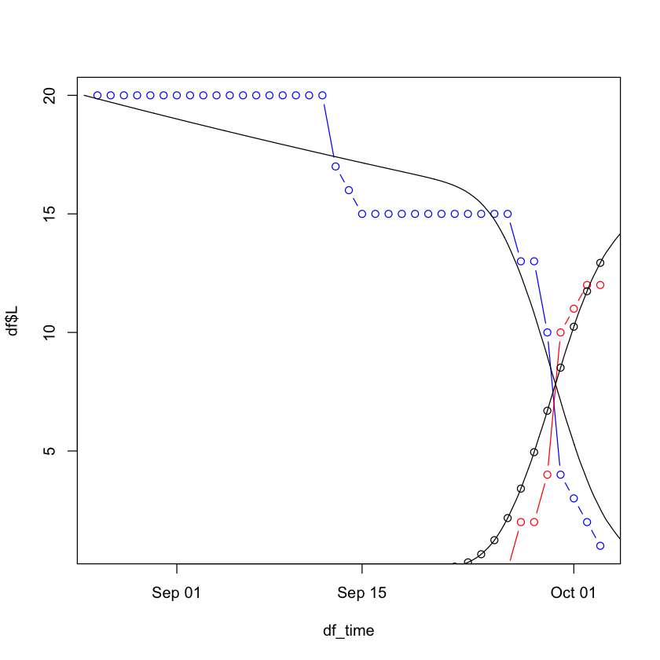

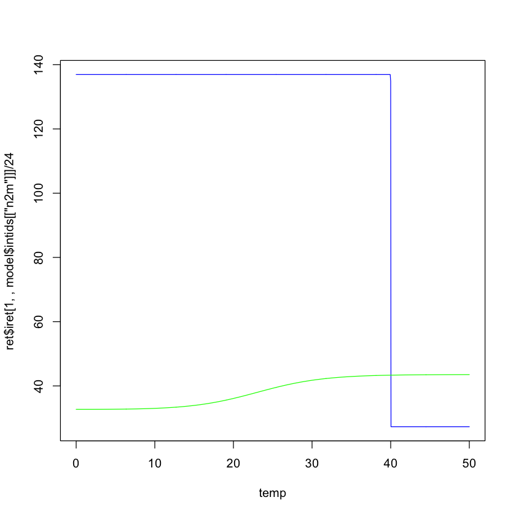

I hope you found this tutorial informative for getting familiar with the PopJSON representation. You can now explore the *Aedes aegypti* model we have prepared for the CSVD Nicosia2025 Workshop using PopJSON.

```
[1] "Model translated to models/model_aegypti.c"
[2] "Model file created: models/model_aegypti.dylib"
```

```
Loaded model with: 7 pops, 59 pars, 34 ints, 7 envs.
```

```
[1] "pop_E"   "pop_Eh"  "pop_L"   "pop_P"   "pop_Afj" "pop_Af"  "pop_Afg"
 [1] "par_E_death_L"       "par_E_death_l"       "par_E_death_R"
 [4] "par_E_death_r"       "par_E_death_X"       "par_E_death_str"
 [7] "par_E_death_dsc"     "par_E_dev_R"         "par_E_dev_r"
[10] "par_E_dev_min"       "par_E_dev_max"       "par_E_to_L"
[13] "par_Eh_dev"          "par_Eh_bs_thr"       "par_Eh_T_thr"
[16] "par_L_to_P"          "par_L_death_L"       "par_L_death_l"
[19] "par_L_death_R"       "par_L_death_r"       "par_L_death_X"
[22] "par_L_death_str"     "par_L_dev_min"       "par_L_dev_max"
[25] "par_L_dev_a"         "par_L_fdens"         "par_L_fdens_str"
[28] "par_L_fdens_mort"    "par_L_fdens_dev"     "par_P_death_L"
[31] "par_P_death_l"       "par_P_death_R"       "par_P_death_r"
[34] "par_P_death_X"       "par_P_death_str"     "par_P_dev_min"
[37] "par_P_dev_max"       "par_P_dev_a"         "par_P_to_A"
[40] "par_A_death_str"     "par_female"          "par_bs_prec"
```

[output cut: 18 more lines]

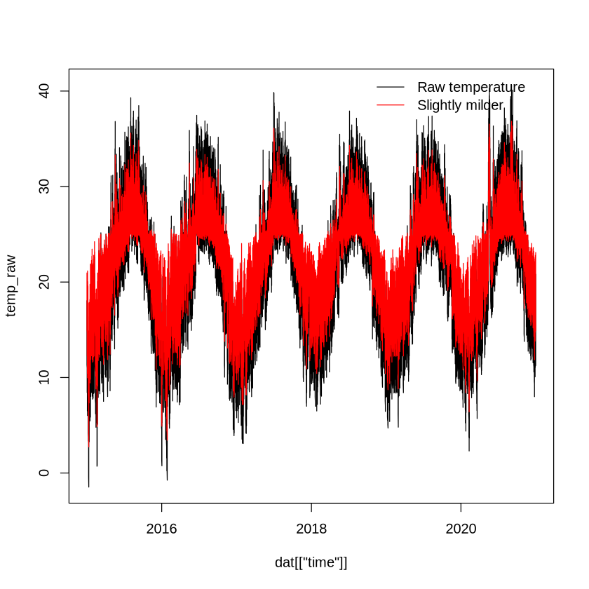

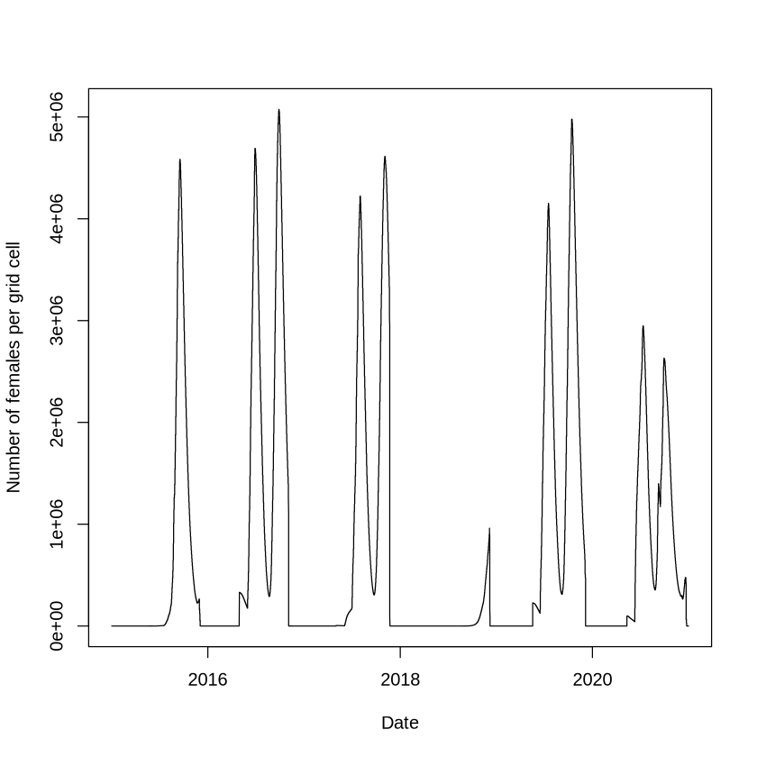